# Macroecology

Daijiang Li

# Reading:

McGill, Brian J. “The what, how and why of doing macroecology.” Global Ecology and Biogeography 28.1 (2019): 6-17. [link to paper](https://onlinelibrary.wiley.com/doi/pdf/10.1111/geb.12855)

Shade, A., Dunn, R. R., Blowes, S. A., Keil, P., Bohannan, B. J., Herrmann, M., … & Chase, J. (2018). Macroecology to unite all life, large and small. Trends in Ecology & Evolution. [link to paper](https://www.indiana.edu/~microbes/publications/Shade_etal_2018_InPress.pdf)

# How do we scale small scale processes to global scales?

The goal of the field of *macroecology* is to explain variation in species abundance, distribution, and diversity, particularly over large geographic scales. It’s useful to talk about at this stage in the semester because we’ve focused a lot on relatively local processes (e.g., competition in a single area). Many macroecological relationships do not have a clear mechanism, often ignore species differences, and almost exclusively do not consider many ecological processes we’ve discussed (e.g., competition, predation). Much of this relates to classic ecological theory on the importance of spatial scale. One idea is that some processes such as competition and predation are important largely important at very local (smaller) scales. As we “zoom out” to more coarser scales, the role of environment becomes more pronounced in determining species diversity and abundance. This is often referred to as the *Eltonian noise hypothesis*.

**The transmutation problem** Sometimes spatial scale can determine whether a pattern is observed at all. That is, a series of relationships at more local scales that can be either positive or negative can result in a clear pattern at larger spatial scales. McGill 2019 goes into a lot of detail about *transmutations*, which explore how different hierarchical scales may be entirely different.

A simple example is in the scaling between a local to macro scale comparison of the relationship between precipitation and productivity. This is the idea that areas that receive more precipitation, on average, have higher productivity (more green biomass, essentially). But this is a bit site-specific, right? We can imagine that productivity could go up with precipitation if plants require more water, but the opposite relationship could be observed as nutrients are washed away from the soil and plants are exposed to too much water. While the local context would suggest no clear relationship, plotting a series of these local relationships yields a general macroecological relationship between precipitation and productivity.

Macroecological relationships allow scientists to undercover generalized *laws* about how biodiversity is distributed. That is, at some spatial scale, the influence of many small scale ecological processes will become relatively unimportant, and global (or macro) scale patterns will emerge. We’ll go over some examples of macroecological laws here, and be sure to read to the McGill paper for more information on the historical and conceptual history of macroecology.

**The dimensionality of macroecology** The scope of macroecology is perhaps best depicted in terms of spatial, temporal, and taxonomic scales of study. How many of these do you think would need to be incorporated to qualify as “macroecology”?

Figure taken from McGill (2019) https://doi.org/10.1111/geb.12855.

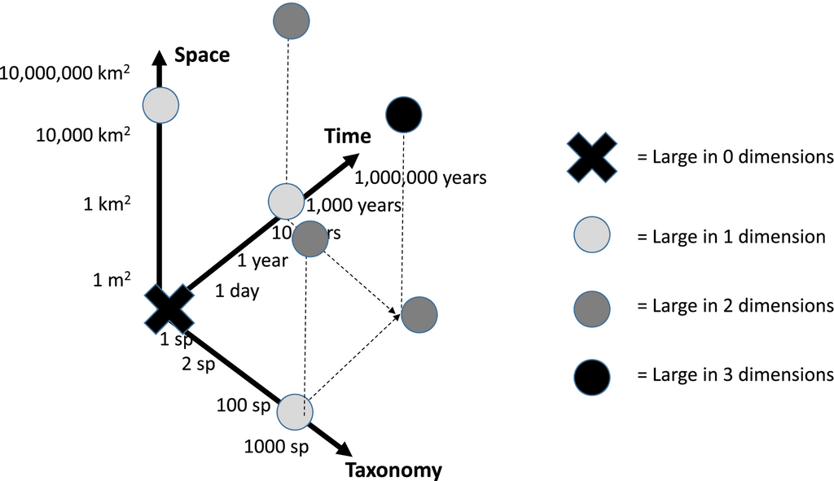

# Latitudinal scaling

Latitude is a major driver of variation in species diversity and range dynamics. Latitudinal variation represents large climatic variation, but could also relate to solar radiation, historical biogeographic processes, land area, etc.

**Latitudinal diversity gradient** Species richness (alpha diversity) tends to be highest near the equator, and declines toward the poles. This pattern has been studied for many different groups of organisms (including parasites!) and is pretty consistent. As with many macroecological patterns though, it is difficult to attribute mechanism to the pattern. Latitude is not really an ecologically driver, but temperature, precipitation, land area, and geological history are all associated with latitude in some form.

*species-energy hypothesis*: the amount of energy sets limits to the species richness an area can achieve (relate this back to food web structure). So more primary productivity in lower latitudes through increased light availability leads to more species in the food web.

*climatic stability hypothesis*: Fluctuating environments tend to cause species extinctions. Environmental conditions tend to fluctuate more at higher latitudes.

**The mid-domain effect** The inherent constraints on latitude and shifting species ranges causes species richness to peak at middle latitudes. That is, assuming the random placement of a species with some fixed latitudinal range, there will still be more species near the equator.

The mid-domain effect doesn’t mean that we shouldn’t look for latitudinal diversity relationships, but we should recognize that they could be the result of randomness. Teasing the randomness from the pattern sometimes requires the use of a *null model*. In the case of the mid-domain effect, a null model would correspond to shuffling species ranges around and measuring the strength and variation in the resulting latitudinal diversity relationship. We also talked about null models a bit when we discussed ecological networks (specifically the importance of a single node to a property of the entire network).

# What is the theory of island biogeography?

This assumes that all islands are reachable by every species in the community with a non-zero probability, and is spatially-implicit (i.e., the actual locations of habitat patches are not considered).

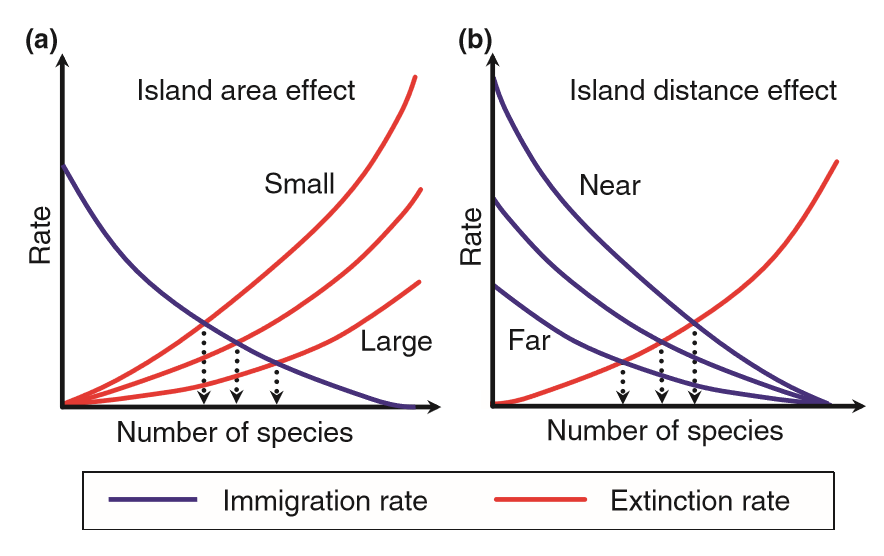

# Species-area relationships

One clear extension, and honestly the original purpose of island biogeography theory, is the study of species-area relationships. The idea here is that increasing geographic area results in a greater number of unique species able to occupy the patch.

Species-area relationships exist in two different forms, depending on how the data are structured. The most related to island biogeography theory is the “island” species-area relationship, where a set of discontiguous habitats are studied, and the area of each patch is related to species richness in that patch. The second – called the “mainland” species-area relationship – considers a contiguous habitat where patches are nested within another.

$$S = cA^{z}$$

where $S$ is the number of species, $A$ is patch area, $z$ describes the shape of the relationships, and $c$ is a constant. $c$ actually describes the number of species we would expect to find in one unit of sampling area (whatever the unit is in the study).

[figure not shown]

The utility of this simple formula is that it suggests that the number of species is a simple function of area, which can help aid in the design of research (how big of a sampling area is required to truly characterize a community?), and to estimate species richness for unobserved sites of known area (is it possible to estimate the number of species on an island we’ve never been to?).

One interesting point is that both the theory of island biogeography and the species-area relationship make the assumption that species colonization and extinction rates are only a function of island area and distance to mainland. That is, species do not fundamentally differ in their dispersal rates, or only do so in a proportional way to one another as a function of island area and isolation (distance to mainland).

**Rapoport’s rule** Latitudinal variation can also be observed species range sizes. Rapoport’s rule argues that the latitudinal ranges (minimum latitude to maximum latitude where a species is found) of species tend to be smaller near the equator. This is actually one of the potential reasons for the latitudinal diversity gradient as well. Smaller latitudinal ranges means that you can pack more species into a given area without so much species overlap, resulting in higher diversity near the equator as a function of smaller latitudinal ranges.

**Bergmann’s rule** A final latitudinal scaling rule we’ll talk about is the scaling of species body sizes with latitude. Bergmann’s rule argues that the average body mass of species increases moving away from the equator (so species body size is smallest at the equator and largest near the poles). The support for this comes in the form of two different ways to examine this.

First, the rule can be examined within a single species across its latitudinal range. This is perhaps the clearest support for the relationship.

Second, the rule can be examined considering all species in a given area, where the mean body size for all organisms within the same trophic level or taxa is tracked across latitude.

These two approaches tend to yield the same results, and oftentimes it’s really tough to get data to address the first way, but fairly straightforward to get data to test the second.

# Species abundance distributions

Species abundance distributions are common ways to describe the structure of ecological communities, and can be compared across spatial gradients. For a given area, the species abundance distribution is really similar to the rank abundance distribution, which we went over previously. Here, the x-axis is species counts (abundances) and the y-axis is the frequency that a species is found with that abundance (so the number of species which fall into a given abundance class). The shape of the relationship is important, because different proposed mechanisms will lead to different shapes. We won’t go over the details about the different models for explaining the shape of the species abundance distribution, but you should know that pretty much every ecological community species abundance distribution has a *hollow curve* shape with many rare species and just a few common species.

**Abundant-center hypothesis** The abundant center hypothesis is a classic distance-abundance relationship, where we relate some measure of distance of a population to an aspect of the species entire range to species abundance at that particular site. Specifically, the abundant center hypothesis states that species density should be highest in the center of species range.

This makes a number of assumptions, some of which are:

- species densities represent equilibrial populations across space
- species interactions (predation, parasitism, etc.) do not influence species density
- geographic center of a range also corresponds to the center of the niche?

So how do we operationalize this relationship? We measure species density across a species range, we calculate the range boundaries and measure distance (either to the range center or to the range boundary) and then we regress species density (y-axis) and the measure of distance we went with. If we measured distance from the range edge, we would expect a negative relationship between distance and abundance (density) if distance was measured as distance from the range center, and a positive relationship if distance was measured as distance from the range edge.

**Occupancy – abundance relationships**

Perhaps one of the best supported macroecological relationships posits that more widespread species are also more locally abundant. That is, species that are found to occupy a larger number of sampled sites are expected to also be quite abundant, calculated as the mean abundance across all occupied sites. From our own work, we have found evidence for this relationship in a wide diversity of taxa from zooplankton to mammals, but the relationships are quite weak. Some have proposed that these relationships can be used to predict abundance from occupancy (which you only need presence-absence data for). This is probably a bad idea though, since the weak explanatory power of the relationship suggests that other factors are important.

Related to occupancy-abundance relationships are a more general class of relationships called ‘distribution-abundance’ relationships, of which occupancy-abundance relationships are one instance of. However, instead of sampling individual sites and estimating occupancy-abundance relationships, some researchers have argued that another relationship exists without having to sample extensively across a species range. That is, much like Rapoport’s rule, there is a general relationship between species geographic range size and mean local abundance. Keep in mind how many of these relationships relate to one another.

### Why do spatial patterns get more attention that spatiotemporal processes?

Macroecology is a developing field, and much of the focus of macroecology has been on large scale *spatial* processes related to the distribution of diversity and abundance. However, McGill emphasizes that the `scale` of the study which makes it `macro` is not necessarily spatial, but some combination of spatial, temporal, and taxonomic scales. Here, we’ll go over a couple of macroecological relationships which consider temporal dimensions of biodiversity.

- **Temporal variability at range margins**

Recall back to our discussion of demographic stochasticity, where we would expect smaller populations to be more sensitive to stochatic extinction. Couple this with the idea that species should have higher abundance toward the center of the species geographic range or climatic niche, and this creates an expectation that marginal populations (those far from the geographic range or climatic niche center) will be smaller. Demographic stochasticity exerts stronger forces on small populations and demographic rates are likely variable across a species range. This creates an expectation that marginal populations should be more variable over time. Think about why and why not this would consitute a macroecological relationship. You should find yourself thinking back to McGill’s three-dimensional space and his composite definition of macroecology.

- **Stability and species richness**

Related to this idea of temporal variability is the idea of richness-stability relationships. Ecological stability is a fuzzy concept, but one measure of stability is temporal variability (described above). Researchers have often found that more diverse (here meaning higher species richness) communities tend to also be more stable (here defined as the temporal variability of the composite community abundance).

### Metabolic theory of ecology

This is related to macroecology, in that it attempts to large-scale taxonomic patterns of body size and other life history traits as a function of metabolic rate. This is often not by looking at metabolic pathways, but by calculating metabolic rate as the amount of oxygen consumed per unit time.

$$B = B_0 * M^{\frac{3}{4}}$$

where B0 is some mass-independent constant in units of watts per kilogram (or power per weight). This means that B is in units of power (e.g., watts) and M is in units of mass (e.g., kg).

There are some clear issues with metabolic scaling theory. Perhaps the most clear is that the lack of true mechanistic basis. Though often presented as mechanistic, confounding or synergistic factors likely explain body size distributions. e.g., temperature is related to metabolic rate of organisms, making it difficult to parse apart the role of temperature and metabolic rate.

### How do we study spatial and temporal macroecological patterns in concert?

- Study spatial pattern for some slices of time and see how it changes
- Adapt the spatial process to a temporal process (spatial occupancy to temporal occupancy)